# CATALINA CROSSING

A History of Speed, Strategy & Santa Barbara Legacy | 2010-2025

Taylor Yorkey  
2026-08-16

# SCORA’S CATALINA CROSSING

[ 15 RACES ] [ 919 FINISHES ] [ 107 CLUBS ] [ 28 SBOCC FINISHES ]

Every year the Southern California Outrigger Racing Association (SCORA) hosts the Catalina Crossing US Outrigger Championships, an outrigger race from Newport to Avalon, Catalina Island and vice versa. It is a 9-man change (relay) race and while the race is advertised as 28 miles, my own Garmin watch has clocked closer to 30.

With this analysis I explore the transition period between the dominance of the heavy Spec canoes to the rise of the lighter Unlimiteds, with a special spotlight on my home team of SBOCC.

## A few notes on data constraints

This analysis focuses only on the Catalina crossing, and specifically only on the Women and Co-Ed divisions. This is due to author preference and available time.

No race was held in 2020 due to Covid restrictions.

2022’s values appear much faster - this is because this year was not a true crossing. Hurricane Hilary caused residual conditions to be too dangerous for a crossing and instead, an out-and-back race was held at Newport. **Consider 2022 to be an outlier in this data.**

# THE RACE HAS GOTTEN FASTER

As one might expect, the lighter boats have led to generally faster times in finishing the Crossing. The sections below explore this in more detail.

## Overall results

This plot shows us:

- The overall range of times
- How the field has changed
- When Unlimiteds start appearing
- Whether the fastest finishes are increasingly Unlimited
- How much variation exists within each year

Hover over the points in graph below to learn more about each finishing crew.

```r
p <- catalina %>%
  filter(!is_dq) %>%
  ggplot(
    aes(
      x = year,
      y = adjusted_finish_seconds / 3600,
      color = boat_type,
      text = paste0(
        "<b>", club, "</b>",
        "<br>Division: ", division,
        "<br>Year: ", year,
        "<br>Place: ", place,
        "<br>Time: ", adjusted_finish_time,
        "<br>Boat: ", canoe
      )
    )
  ) +
  geom_jitter(
    width = 0.15,
    height = 0,
    alpha = 0.65,
    size = 2.5
  ) +

  scale_color_manual(
    values = c(
      "Unlimited" = "#264653",
      "Spec" = "#E76F51",
      "Other" = "#F4A261"
      )
    ) +

  scale_x_continuous(
    breaks = seq(2010, 2025, by = 2)
  ) +

  labs(
    title = "Catalina Crossing finishing times, 2010–2025",
    subtitle = "Each point represents one finishing crew; times are adjusted for known/assumed staggered starts",
    x = NULL,
    y = "Finishing time (hours)",
    color = "Boat type"
  )

ggplotly(
  p,
  tooltip = "text"
) %>%
  layout(
    hoverlabel = list(align = "left")
  )
```

[interactive chart not shown]

*Note: in this graph and several following, dots lower on the y-axis indicate faster finishing times.*

## How the race’s fastest times have changed

Has the fastest finishing time gotten *faster* over the years? Surprisingly, the answer is not an obvious yes. There may indeed be some slight trend towards faster times, but the Unlimiteds contribute markedly towards this trend.

```r
fastest_by_year <- catalina %>%
  filter(!is_dq) %>%
  group_by(year) %>%
  summarise(
    fastest_seconds = min(adjusted_finish_seconds),
    fastest_time = first(
      adjusted_finish_time[
        which.min(adjusted_finish_seconds)
      ]
    ),
    winning_club = first(
      club[
        which.min(adjusted_finish_seconds)
      ]
    ),
    winning_division = first(
      division[
        which.min(adjusted_finish_seconds)
      ]
    ),
    .groups = "drop"
  )

p <- ggplot(
  fastest_by_year,
  aes(
    x = year,
    y = fastest_seconds / 60,
    text = paste0(
      "<b>", year, "</b>",
      "<br>Fastest time: ", fastest_time,
      "<br>Club: ", winning_club,
      "<br>Division: ", winning_division
    )
  )
) +
  geom_line(linewidth = 1) +
  geom_point(size = 3, color = "#264653") +
  scale_x_continuous(
    breaks = seq(2010, 2025, by = 2)
  ) +
  labs(
    title = "The fastest Catalina finishes over time",
    subtitle = "Adjusted finishing time of the fastest recorded crew each year",
    x = NULL,
    y = "Finishing time (minutes)"
  )

ggplotly(p, tooltip = "text")
```

[interactive chart not shown]

## Median performance of the entire field

Catalina finishing times have varied considerably from year to year, but there is not an obvious steady trend toward faster performances. The pronounced swings in the median suggest that race conditions and field composition may matter as much as changes in crew or canoe performance.

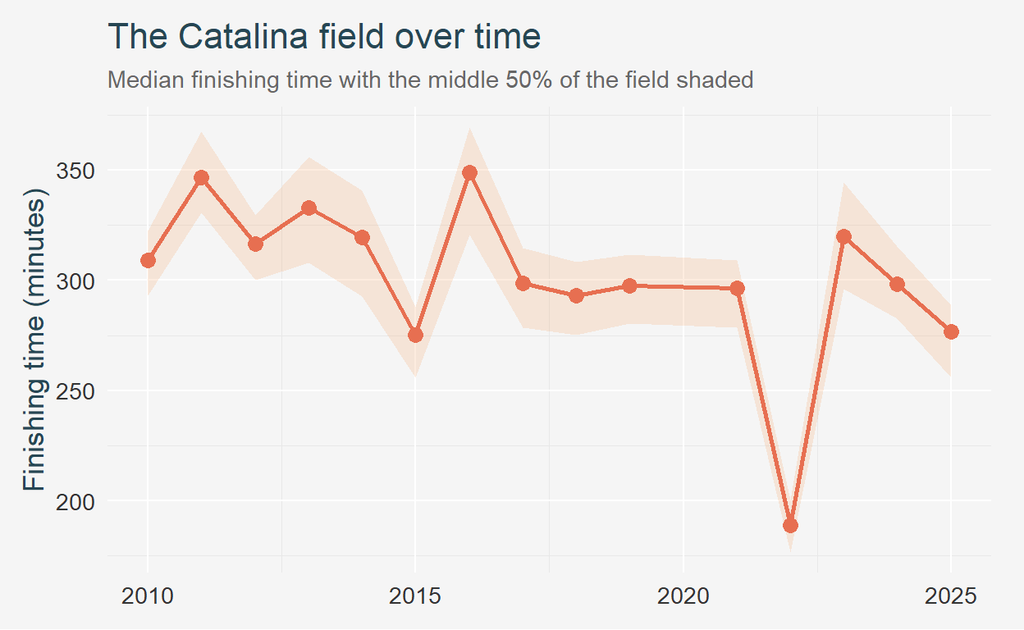

```r
field_trend <- catalina %>%
  filter(!is_dq) %>%
  group_by(year) %>%
  summarise(
    median_seconds = median(adjusted_finish_seconds),
    p25_seconds = quantile(adjusted_finish_seconds, 0.25),
    p75_seconds = quantile(adjusted_finish_seconds, 0.75),
    .groups = "drop"
  )

ggplot(
  field_trend,
  aes(
    x = year,
    y = median_seconds / 60
  )
) +
  geom_ribbon(
    aes(
      ymin = p25_seconds / 60,
      ymax = p75_seconds / 60,
    ),
    alpha = 0.2,
    fill = "#F4A261"
  ) +
  geom_line(linewidth = 1, color = "#E76F51") +
  geom_point(size = 3, color = "#E76F51") +
  labs(
    title = "The Catalina field over time",
    subtitle = "Median finishing time with the middle 50% of the field shaded",
    x = NULL,
    y = "Finishing time (minutes)"
  )
```

*Reminder that 2022 is an outlier year and not an actual crossing.*

# THE RISE OF THE UNLIMITED

[See this article from Ozone Outrigger Zone about paddling a Malolo for the first time.](https://store.outriggerzone.com/product-insights/unlimited-potential-malolo-oc6/)

## The changing Catalina fleet

Has Catalina become faster partly because the composition of the fleet changed?

This is a tricky question. The Catalina fleet has changed substantially over time, with Unlimited canoes becoming an increasingly prominent part of the field. This shift matters when interpreting historical finishing times: if Unlimited canoes are inherently faster than Spec canoes, then a growing share of Unlimited crews could pull the overall field median downward even without a corresponding improvement in performance within either boat type.

This makes fleet composition an important piece of the puzzle, but it does not by itself tell us how much of the change in finishing times is attributable to the canoes themselves. To tease that apart, we can compare finishing times for Unlimited and Spec crews separately.

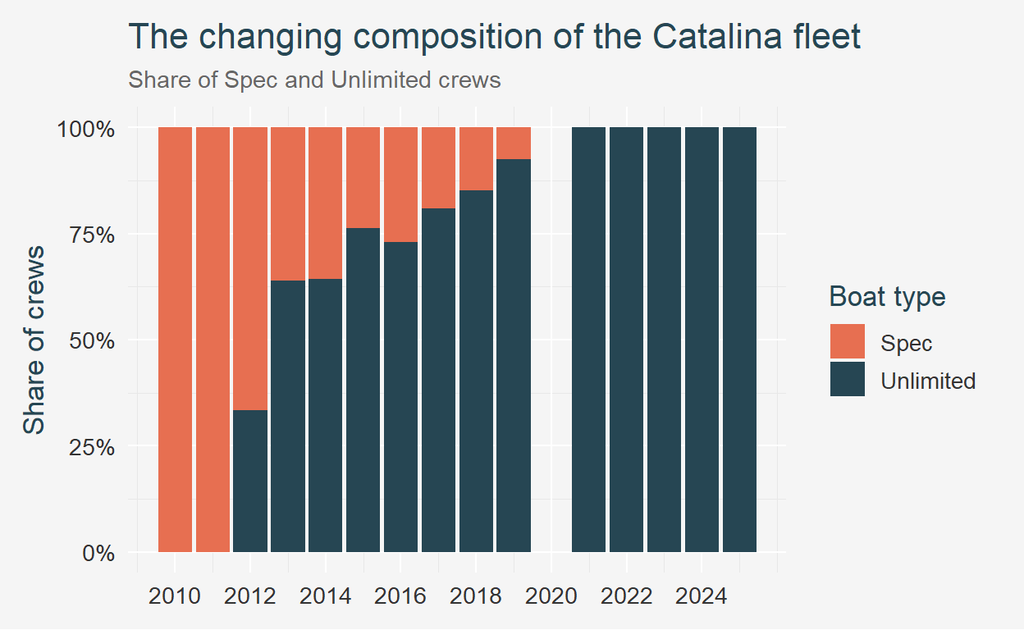

```r
fleet_composition <- catalina %>%
  filter(
    !is_dq,
    boat_type %in% c("Unlimited", "Spec")
  ) %>%
  count(year, boat_type) %>%
  group_by(year) %>%
  mutate(
    pct = n / sum(n)
  ) %>%
  ungroup()

ggplot(
  fleet_composition,
  aes(
    x = year,
    y = pct,
    fill = boat_type
  )
) +
  geom_col() +
  scale_fill_manual(
    values = c(
      "Unlimited" = "#264653",
      "Spec" =  "#E76F51"
      )
    )+
  scale_y_continuous(
    labels = percent,
    limits = c(0, 1)
  ) +
  scale_x_continuous(
    breaks = seq(2010, 2025, by = 2)
  ) +
  labs(
    title = "The changing composition of the Catalina fleet",
    subtitle = "Share of Spec and Unlimited crews",
    x = NULL,
    y = "Share of crews",
    fill = "Boat type"
  )
```

## How much faster are Unlimiteds?

Unlimited canoes show a consistently faster median finishing time than Spec canoes, but the gap between the two has varied considerably from year to year. While in general the Unlimiteds are faster than the Specs, crew, conditions, and various other factors contribute to the gap between the two vessels types.

```r
boat_type_summary <- catalina %>%
  filter(
    !is_dq,
    boat_type %in% c("Unlimited", "Spec")
  ) %>%
  group_by(year, boat_type) %>%
  summarise(
    median_seconds = median(adjusted_finish_seconds),
    n = n(),
    .groups = "drop"
  )
```

```r
p <- ggplot(
  boat_type_summary,
  aes(
    x = year,
    y = median_seconds / 60,
    color = boat_type,
    group = boat_type,
    text = paste0(
      "<b>", boat_type, "</b>",
      "<br>Year: ", year,
      "<br>Median: ",
      sprintf(
        "%d:%02d",
        floor(median_seconds / 60),
        round(median_seconds %% 60)
      ),
      "<br>Crews: ", n
    )
  )
) +
  geom_line(linewidth = 1.1) +
  geom_point(size = 3) +
  scale_color_manual(
    values = c(
      "Unlimited" = "#264653",
      "Spec" = "#E76F51"
    )
  ) +
  scale_x_continuous(
    breaks = seq(2010, 2025, by = 2)
  ) +
  labs(
    title = "Unlimited vs. Spec: how has performance changed?",
    subtitle = "Median adjusted finishing time by boat type",
    x = NULL,
    y = "Median finishing time (minutes)",
    color = "Boat type"
  ) +
  theme_catalina(base_size = 13)

ggplotly(
  p,
  tooltip = "text"
) %>%
  layout(
    hoverlabel = list(align = "left"),
    plot_bgcolor = "#F5F5F5",
    paper_bgcolor = "#F5F5F5"
  )
```

[interactive chart not shown]

## The Unlimited advantage

The Unlimited advantage is substantial in most years, with Unlimited crews generally finishing well ahead of Spec crews. However, the size of that advantage fluctuates considerably from year to year, suggesting that race conditions and the composition of each year’s field can amplify or diminish the performance gap.

Positive values in the graph below indicate that Unlimited crews had a faster median time than Spec crews; larger values indicate a larger advantage

```r
unlimited_advantage <- catalina %>%
  filter(
    !is_dq,
    boat_type %in% c("Unlimited", "Spec")
  ) %>%
  group_by(year, boat_type) %>%
  summarise(
    median_seconds = median(adjusted_finish_seconds),
    .groups = "drop"
  ) %>%
  pivot_wider(
    names_from = boat_type,
    values_from = median_seconds
  ) %>%
  mutate(
    unlimited_advantage_minutes =
      (`Spec` - `Unlimited`) / 60
  )

p <- ggplot(
  unlimited_advantage,
  aes(
    x = year,
    y = unlimited_advantage_minutes,
    text = paste0(
      "<b>", year, "</b>",
      "<br>Unlimited advantage: ",
      round(unlimited_advantage_minutes, 1),
      " minutes"
    )
  )
) +
  geom_hline(
    yintercept = 0,
    linetype = "dashed"
  ) +
  geom_line(linewidth = 1) +
  geom_point(size = 3, color = "#264653") +
  scale_x_continuous(
    breaks = seq(2010, 2025, by = 2)
  ) +
  labs(
    title = "How large is the Unlimited advantage?",
    subtitle = "Difference between median Spec and Unlimited finishing times",
    x = NULL,
    y = "Unlimited advantage (minutes)"
  )

ggplotly(p, tooltip = "text")
```

[interactive chart not shown]

# SANTA BARBARA AT CATALINA

Santa Barbara Outrigger Canoe Club has been a consistent presence at Catalina throughout the historical record, with crews competing across multiple divisions and boat types. The results show both the breadth of SBOCC’s participation and how the club’s performance has evolved as the Catalina fleet itself has changed.

```r
# Santa Barbara results
sbocc <- catalina %>%
  filter(is_santa_barbara)

p <- sbocc %>%
  filter(!is_dq) %>%
  ggplot(
    aes(
      x = year,
      y = adjusted_finish_seconds / 60,
      color = boat_type,
      shape = division,
      text = paste0(
        "<b>", year, "</b>",
        "<br>Division: ", division,
        "<br>Boat type: ", boat_type,
        "<br>Place: ", place,
        "<br>Time: ", adjusted_finish_time,
        "<br>Canoe: ", canoe
      )
    )
  ) +
  geom_point(
    size = 4,
    alpha = 0.85,
    stroke = 0.8
  ) +
  scale_color_manual(
    values = c(
      "Unlimited" = "#264653",
      "Spec" = "#E76F51",
      "Other" = "#F4A261"
    )
  ) +
  scale_x_continuous(
    breaks = seq(2010, 2025, by = 2)
  ) +
  labs(
    title = "Santa Barbara at Catalina",
    subtitle = "Every Santa Barbara Outrigger Canoe Club finish in the historical record",
    x = NULL,
    y = "Adjusted finishing time (minutes)",
    color = "Boat type",
    shape = "Division"
  ) +
  theme_catalina(base_size = 13) +
  theme(
    legend.position = "right"
  )

ggplotly(
  p,
  tooltip = "text",
  height = 650
) %>%
  layout(
    hoverlabel = list(
      align = "left"
    ),
    plot_bgcolor = "#F5F5F5",
    paper_bgcolor = "#F5F5F5"
  )
```

[interactive chart not shown]

Because these results span different divisions, crew compositions, and canoe types, finishing times aren’t directly comparable across every point. Still, the record provides a useful picture of SBOCC’s Catalina history, and highlights some particularly strong performances that are worth exploring in more detail.

## Santa Barbara relative performance

How competitive was Santa Barbara within its division each year?

Absolute finishing times can be difficult to compare across Catalina races, since conditions and field strength vary from year to year. Looking at Santa Barbara’s percentile within its own year and division provides a more consistent measure of competitiveness: **a higher percentile means the crew finished closer to the front of its division.**

```r
p <- sbocc %>%
  filter(!is_dq) %>%
  ggplot(
    aes(
      x = year,
      y = performance_percentile,
      color = boat_type,
      text = paste0(
        "<b>", year, "</b>",
        "<br>Division: ", division,
        "<br>Boat type: ", boat_type,
        "<br>Place: ", place,
        "<br>Field size: ", division_field_size,
        "<br>Performance percentile: ",
        percent(performance_percentile, accuracy = 1)
      )
    )
  ) +
  geom_hline(
    yintercept = 0.5,
    linetype = "dashed",
    color = "#999999",
    linewidth = 0.7
  ) +
  geom_point(
    size = 4,
    alpha = 0.9,
    stroke = 0.8
  ) +
  scale_color_manual(
    values = c(
      "Unlimited" = "#264653",
      "Spec" = "#E76F51"
    )
  ) +
  scale_y_continuous(
    labels = percent,
    limits = c(0, 1),
    breaks = seq(0, 1, by = 0.25)
  ) +
  scale_x_continuous(
    breaks = seq(2010, 2025, by = 2)
  ) +
  labs(
    title = "How competitive has Santa Barbara been?",
    subtitle = "Santa Barbara's position within its year/division field",
    x = NULL,
    y = "Performance percentile",
    color = "Boat type"
  ) +
  theme_catalina(base_size = 13)

ggplotly(
  p,
  tooltip = "text",
  height = 600
) %>%
  layout(
    hoverlabel = list(
      align = "left"
    ),
    plot_bgcolor = "#F5F5F5",
    paper_bgcolor = "#F5F5F5"
  )
```

[interactive chart not shown]

This view highlights years when Santa Barbara punched above or below the middle of its division, independent of the overall pace of the race. It also makes it easier to distinguish a genuinely strong result from a fast finishing time that occurred in an unusually fast or slow year.

*Note: Percentiles are calculated within each year/division field; results from small fields should be interpreted cautiously.*

## Santa Barbara’s best years

Looking across individual results, Santa Barbara has had several standout Catalina performances across different eras and boat types. The strongest results aren’t necessarily the fastest absolute finishing times; percentile helps identify performances that were particularly competitive relative to the other crews in that year’s division.

The table below shows Santa Barbara’s highest-performing results, ranked by position within the division.

```r
sbocc_best <- sbocc %>%
  filter(!is_dq) %>%
  arrange(desc(performance_percentile)) %>%
  select(
    Year = year,
    `Overall Place` = place,
    Division = division,
    `Boat Type` = boat_type,
    Time = adjusted_finish_time,
    `Field Size` = division_field_size,
    `Performance Percentile` = performance_percentile
  ) %>%
  mutate(
    `Performance Percentile` =
      percent(`Performance Percentile`, accuracy = 1)
  )

datatable(
  sbocc_best,
  options = list(
    pageLength = 10,
    order = list(list(6, "desc")),
    autoWidth = FALSE,
    scrollX = FALSE
  ),
  width = "100%",
  rownames = FALSE
)
```

| Year | Overall Place | Division | Boat Type | Time | Field Size | Performance Percentile |
| --- | --- | --- | --- | --- | --- | --- |
| 2016 | 1 | co-ed - open unlimited | Unlimited | 04:35:54 | 14 | 100% |
| 2010 | 11 | co-ed - open | Other | 04:30:58 | 25 | 92% |
| 2022 | 6 | women - unlimited | Unlimited | 02:51:52 | 25 | 88% |
| 2025 | 14 | women - unlimited | Unlimited | 04:10:47 | 26 | 84% |
| 2016 | 25 | co-ed - open | Other | 05:27:20 | 11 | 80% |
| 2014 | 17 | women - spec | Spec | 05:17:11 | 10 | 78% |
| 2023 | 13 | women - unlimited | Unlimited | 04:53:46 | 31 | 77% |
| 2016 | 11 | co-ed - open unlimited | Unlimited | 05:05:30 | 14 | 69% |
| 2015 | 7 | women - unlimited | Unlimited | 04:01:30 | 19 | 67% |
| 2024 | 23 | women - unlimited | Unlimited | 04:52:21 | 24 | 65% |

[output cut: 18 more lines]

# EXPLORE THE DATA

The table below contains the complete historical Catalina Crossing record used in this analysis. Use the column filters to explore particular years, clubs, divisions, or boat types. The search and download tools can also be used to investigate the underlying results in more detail.

## All Results

```r
results_table <- catalina %>%
  select(
    Year = year,
    Place = place,
    Club = club,
    Division = division,
    `Boat Type` = boat_type,
    Canoe = canoe,
    `Raw Time` = finish_time,
    `Adjusted Time` = adjusted_finish_time,
    `Start Adjustment` = start_adjustment_minutes,
    DQ = is_dq
  )

datatable(
  results_table,
  filter = "top",
  rownames = FALSE,
  class = "display compact stripe",
  options = list(
    pageLength = 5,
    scrollX = TRUE,
    autoWidth = FALSE,
    dom = "Bfrtip",
    buttons = c("copy", "csv"),
    order = list(
      list(0, "desc"),
      list(1, "asc")
    ),
    columnDefs = list(
      list(width = "6%", targets = 0),
      list(width = "6%", targets = 1),
      list(width = "24%", targets = 2),
      list(width = "18%", targets = 3),
      list(width = "10%", targets = 4),
      list(width = "8%", targets = 5),
      list(width = "9%", targets = 6),
      list(width = "10%", targets = 7),
      list(width = "9%", targets = 8)
    )
  )
)
```

| Year | Place | Club | Division | Boat Type | Canoe | Raw Time | Adjusted Time | Start Adjustment | DQ |
| --- | --- | --- | --- | --- | --- | --- | --- | --- | --- |
| 2010 | 1 | Lanakila Outrigger Canoe Club | women - spec | Spec | 116 | 04:26:52 | 04:26:52 | 0 | False |
| 2010 | 2 | Hanohano Outrigger Canoe Club | women - spec | Spec | 6 | 04:30:39 | 04:30:39 | 0 | False |
| 2010 | 3 | Marina del Rey Outrigger Canoe Club | women - spec | Spec | 135 | 04:32:06 | 04:32:06 | 0 | False |
| 2010 | 4 | Outrigger Canoe Club | women - spec | Spec | 118 | 04:33:32 | 04:33:32 | 0 | False |
| 2010 | 5 | Imua Outrigger Canoe Club | women - masters | Other | 27 | 04:35:57 | 04:35:57 | 0 | False |
| 2010 | 6 | Newport Aquatic Center (NAC) | co-ed - open | Other | 300 | 04:43:24 | 04:23:24 | -20 | False |
| 2010 | 7 | Lanakila Outrigger Canoe Club | women - bradley | Other | 104 | 04:43:49 | 04:43:49 | 0 | False |
| 2010 | 8 | Oceanside Outrigger Canoe Club | women - bradley | Other | 28 | 04:48:05 | 04:48:05 | 0 | False |
| 2010 | 9 | Hanohano Outrigger Canoe Club | women - bradley | Other | 2 | 04:48:14 | 04:48:14 | 0 | False |
| 2010 | 10 | Kupa'a Mau | co-ed - open | Other | 213 | 04:49:50 | 04:29:50 | -20 | False |

[output cut: 909 more lines]

## Club Appearances

Catalina has attracted a relatively consistent core of clubs over the years, alongside a long tail of clubs appearing only occasionally. The clubs with the most appearances aren’t necessarily the clubs with the strongest individual results, but their repeated participation makes them an important part of the race’s history.

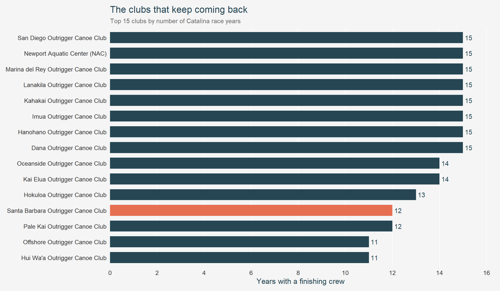

```r
club_summary <- catalina %>%
  filter(!is_dq) %>%
  group_by(club) %>%
  summarise(
    races = n_distinct(year),
    crews = n(),
    best_place = min(place, na.rm = TRUE),
    .groups = "drop"
  ) %>%
  mutate(
    highlight = if_else(
      club == "Santa Barbara Outrigger Canoe Club",
      "Santa Barbara",
      "Other"
    )
  ) %>%
  arrange(desc(races), desc(crews)) %>%
  slice_head(n = 15)

ggplot(
  club_summary,
  aes(
    x = reorder(club, races),
    y = races,
    fill = highlight,
    text = paste0(
      "<b>", club, "</b>",
      "<br>Years raced: ", races,
      "<br>Total crews: ", crews,
      "<br>Best overall place: ", best_place
    )
  )
) +
  geom_col(
    width = 0.7
  ) +
  scale_fill_manual(
    values = c(
      "Santa Barbara" = "#E76F51",
      "Other" = "#264653"
    )
  )+
  geom_text(
    aes(label = races),
    hjust = -0.25,
    color = "#264653",
    size = 4
  ) +
  coord_flip() +
  scale_y_continuous(
    breaks = seq(0, max(club_summary$races) + 1, by = 2),
    expand = expansion(mult = c(0, 0.08))
  ) +
  labs(
    title = "The clubs that keep coming back",
    subtitle = "Top 15 clubs by number of Catalina race years",
    x = NULL,
    y = "Years with a finishing crew",
  ) +
  theme_catalina(base_size = 13) +
  theme(
    legend.position = "none",
    panel.grid.major.y = element_blank(),
    panel.grid.minor = element_blank()
  )
```

# ABOUT THE DATA

This data was compiled from historical race results [available from SCORA’s website](https://www.scora.org/race-results/). The data has been cleaned and organized, but some errors may exist. Please let me know if you find any errors!